# PRÁCTICA DE ESTADÍSTICA

Armando Olivares

19 de noviembre de 2017

Los datos siguientes contienen los precios y otros atributos de unos 54.000 diamantes y se encuentran en http://ggplot2.tidyverse.org/reference/diamonds.html. También allí hay una descripción de lo que significan las variables. El objetivo del ejercicio es hacer un análisis descriptivo, con el fin de entender los datos y las posibles relaciones entre las variables.

# 1. Cargamos los datos y librerias a utilizar

```r
rm(list = ls())
##Cargamos las librerias a utilizar
suppressWarnings(suppressMessages(library(ggplot2)))
suppressWarnings(suppressMessages(library(dplyr)))
suppressWarnings(suppressMessages(library(corrplot)))
data(diamonds)
glimpse(diamonds)
```

```
## Observations: 53,940
## Variables: 10
## $ carat   <dbl> 0.23, 0.21, 0.23, 0.29, 0.31, 0.24, 0.24, 0.26, 0.22, ...
## $ cut     <ord> Ideal, Premium, Good, Premium, Good, Very Good, Very G...
## $ color   <ord> E, E, E, I, J, J, I, H, E, H, J, J, F, J, E, E, I, J, ...
## $ clarity <ord> SI2, SI1, VS1, VS2, SI2, VVS2, VVS1, SI1, VS2, VS1, SI...
## $ depth   <dbl> 61.5, 59.8, 56.9, 62.4, 63.3, 62.8, 62.3, 61.9, 65.1, ...
## $ table   <dbl> 55, 61, 65, 58, 58, 57, 57, 55, 61, 61, 55, 56, 61, 54...
## $ price   <int> 326, 326, 327, 334, 335, 336, 336, 337, 337, 338, 339,...
## $ x       <dbl> 3.95, 3.89, 4.05, 4.20, 4.34, 3.94, 3.95, 4.07, 3.87, ...
## $ y       <dbl> 3.98, 3.84, 4.07, 4.23, 4.35, 3.96, 3.98, 4.11, 3.78, ...
## $ z       <dbl> 2.43, 2.31, 2.31, 2.63, 2.75, 2.48, 2.47, 2.53, 2.49, ...
```

## Exploramos nuestro dataset para conocer un poco los datos

Primero las dimensiones:

```r
dim(diamonds)
```

```
## [1] 53940    10
```

Luego algunas medidas de tendencia central:

```r
summary(diamonds)
```

```
##      carat               cut        color        clarity
##  Min.   :0.2000   Fair     : 1610   D: 6775   SI1    :13065
##  1st Qu.:0.4000   Good     : 4906   E: 9797   VS2    :12258
##  Median :0.7000   Very Good:12082   F: 9542   SI2    : 9194
##  Mean   :0.7979   Premium  :13791   G:11292   VS1    : 8171
##  3rd Qu.:1.0400   Ideal    :21551   H: 8304   VVS2   : 5066
##  Max.   :5.0100                     I: 5422   VVS1   : 3655
##                                     J: 2808   (Other): 2531
##      depth           table           price             x
##  Min.   :43.00   Min.   :43.00   Min.   :  326   Min.   : 0.000
##  1st Qu.:61.00   1st Qu.:56.00   1st Qu.:  950   1st Qu.: 4.710
##  Median :61.80   Median :57.00   Median : 2401   Median : 5.700
##  Mean   :61.75   Mean   :57.46   Mean   : 3933   Mean   : 5.731
##  3rd Qu.:62.50   3rd Qu.:59.00   3rd Qu.: 5324   3rd Qu.: 6.540
##  Max.   :79.00   Max.   :95.00   Max.   :18823   Max.   :10.740
##
##        y                z
##  Min.   : 0.000   Min.   : 0.000
##  1st Qu.: 4.720   1st Qu.: 2.910
##  Median : 5.710   Median : 3.530
##  Mean   : 5.735   Mean   : 3.539
##  3rd Qu.: 6.540   3rd Qu.: 4.040
##  Max.   :58.900   Max.   :31.800
##
```

Y la estructura de nuestros datos:

```r
str(diamonds)
```

```
## Classes 'tbl_df', 'tbl' and 'data.frame':    53940 obs. of  10 variables:
##  $ carat  : num  0.23 0.21 0.23 0.29 0.31 0.24 0.24 0.26 0.22 0.23 ...
##  $ cut    : Ord.factor w/ 5 levels "Fair"<"Good"<..: 5 4 2 4 2 3 3 3 1 3 ...
##  $ color  : Ord.factor w/ 7 levels "D"<"E"<"F"<"G"<..: 2 2 2 6 7 7 6 5 2 5 ...
##  $ clarity: Ord.factor w/ 8 levels "I1"<"SI2"<"SI1"<..: 2 3 5 4 2 6 7 3 4 5 ...
##  $ depth  : num  61.5 59.8 56.9 62.4 63.3 62.8 62.3 61.9 65.1 59.4 ...
##  $ table  : num  55 61 65 58 58 57 57 55 61 61 ...
##  $ price  : int  326 326 327 334 335 336 336 337 337 338 ...
##  $ x      : num  3.95 3.89 4.05 4.2 4.34 3.94 3.95 4.07 3.87 4 ...
##  $ y      : num  3.98 3.84 4.07 4.23 4.35 3.96 3.98 4.11 3.78 4.05 ...
##  $ z      : num  2.43 2.31 2.31 2.63 2.75 2.48 2.47 2.53 2.49 2.39 ...
```

**Observamos que nuestro dataset contienes 53.940 diamante con 10 variables que los definen, tenemos 3 variables categóricas y 7 variables numéricas.**

# 2. Exploramos las Frecuencias de las Variables Categóricas

```r
table(diamonds$cut)
```

```
##
##      Fair      Good Very Good   Premium     Ideal
##      1610      4906     12082     13791     21551
```

```r
table(diamonds$color)
```

```
##
##     D     E     F     G     H     I     J
##  6775  9797  9542 11292  8304  5422  2808
```

```r
table(diamonds$clarity)
```

```
##
##    I1   SI2   SI1   VS2   VS1  VVS2  VVS1    IF
##   741  9194 13065 12258  8171  5066  3655  1790
```

Y las frecuencias Relativas:

```r
prop.table(table(diamonds$cut))*100
```

```
##
##      Fair      Good Very Good   Premium     Ideal
##  2.984798  9.095291 22.398962 25.567297 39.953652
```

```r
prop.table(table(diamonds$color))*100
```

```
##
##         D         E         F         G         H         I         J
## 12.560252 18.162773 17.690026 20.934372 15.394883 10.051910  5.205784
```

```r
prop.table(table(diamonds$clarity))*100
```

```
##
##        I1       SI2       SI1       VS2       VS1      VVS2      VVS1
##  1.373749 17.044865 24.221357 22.725250 15.148313  9.391917  6.776047
##        IF
##  3.318502
```

**El corte predominante es el *Ideal*, el color predominante es el *G* y la claridad es *SI1***

# 3. Exploramos Graficamente las variables

### Primero revisamos las correlaciones entre variables

#### Para ello tomamos una muestra aleatoria de 10.000 elementos de nuestro set de datos esto con el fin de no tener demasiado tiempo de computo.

```r
set.seed(1)
index_sample = sample(x = 1:nrow(diamonds), 10000)
diamonds_sample= diamonds[index_sample, ]
head(diamonds_sample)
```

```
## # A tibble: 6 x 10
##   carat       cut color clarity depth table price     x     y     z
##   <dbl>     <ord> <ord>   <ord> <dbl> <dbl> <int> <dbl> <dbl> <dbl>
## 1  1.51      Fair     J     SI2  65.1  59.0  5801  7.13  7.09  4.63
## 2  1.27   Premium     G     VS2  61.0  60.0  8549  6.93  6.97  4.24
## 3  0.41     Ideal     D     SI1  63.0  53.0   744  4.74  4.79  3.00
## 4  0.36     Ideal     H     SI1  62.3  53.0   538  4.57  4.61  2.86
## 5  1.05   Premium     F     SI1  62.8  59.0  4879  6.43  6.40  4.03
## 6  0.55 Very Good     F     VS1  61.2  56.4  1975  5.28  5.33  3.25
```

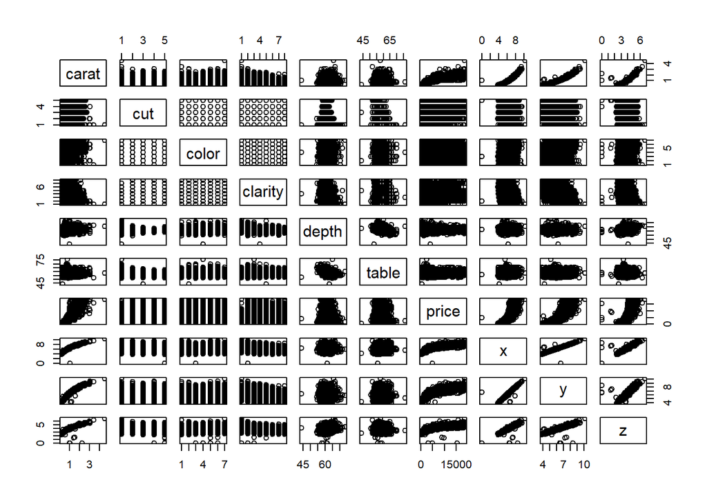

```r
pairs(diamonds_sample)
```

**Con este gráfico es difícil poder observar las relaciones con claridad, por lo que exploraremos solo las variables númericas**

## Seleccionamos solo númericas:

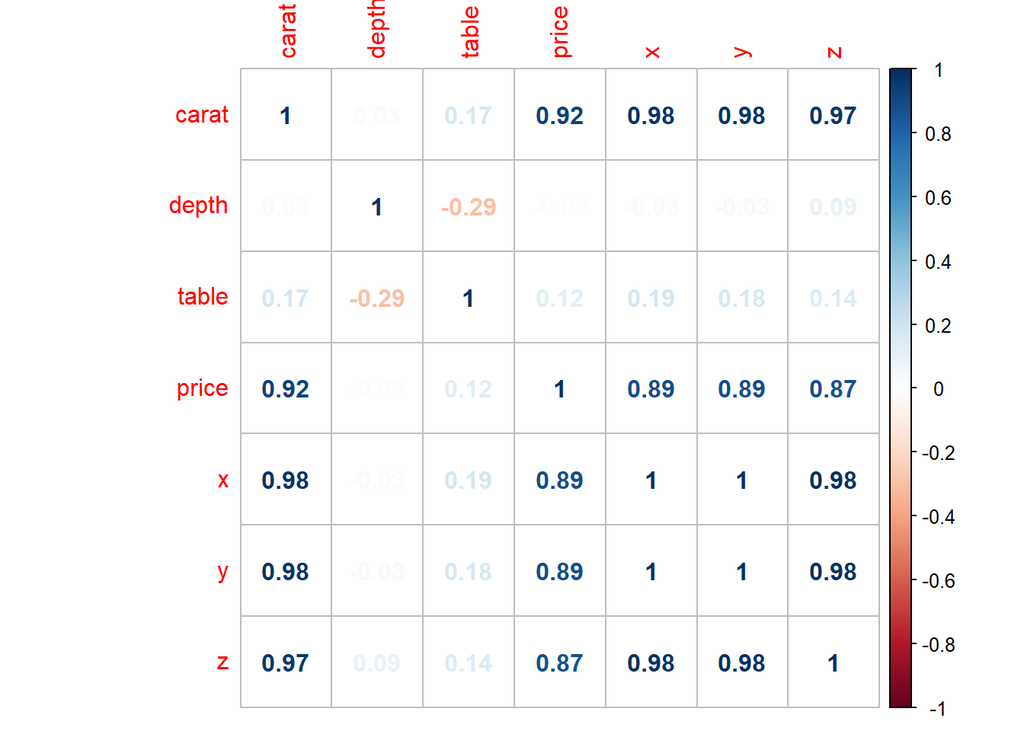

```r
diamonds_numericos <- diamonds_sample[,sapply(diamonds_sample, is.numeric)]
corrplot(cor(diamonds_numericos), method = "number")
```

**Se observa (como es de esperar) que la variable precio está muy correlacionado con los quilates (carat), y con las dimensiones ó talla (x,y,z) del diamante, con la variable table no parece haber relación.**

#### Gráfico de Carats en Funcion del precio

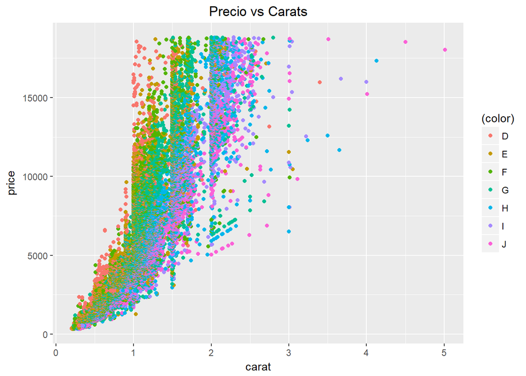

```r
ggplot(data = diamonds, aes(x = carat, y = price, col = (color)) )+ labs(title = "Precio vs Carats")+theme(plot.title = element_text(hjust = 0.5)) + geom_point()
```

##### **dificil de interpretar, mejor realizamos un gráfico separando por color, aunque la relación parece ser exponencial**

#### Graficamos Carats en Funcion del precio agrupados por color del diamante

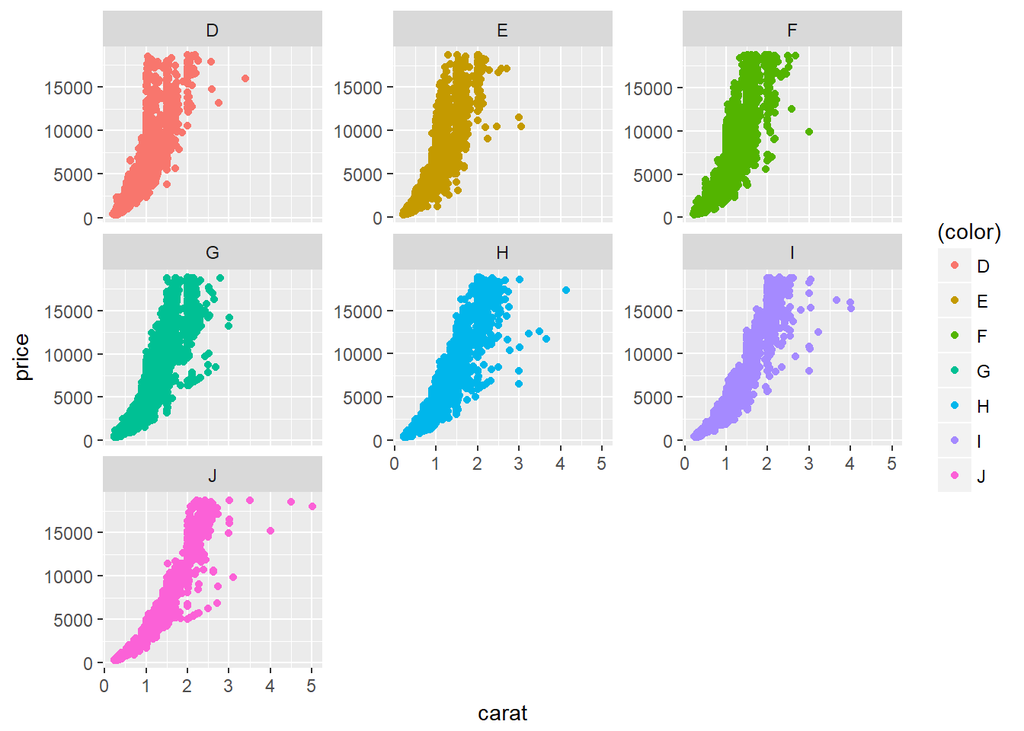

```r
ggplot(data = diamonds, aes(x = carat, y = price, col = (color))) + geom_point()+facet_wrap(~color, scales="free_y")
```

**Se observa graficamente la clara relación entre precio-quilate, con mayor o menor pendiente dependiendo del color.**

#### Graficamos Carats en Funcion del precio agrupados por la claridad del diamante

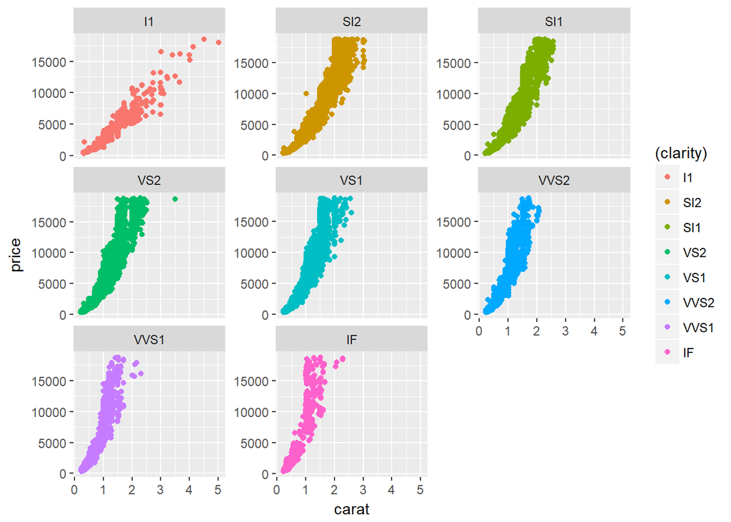

```r
ggplot(data = diamonds, aes(x = carat, y = price, col = (clarity))) + geom_point()+facet_wrap(~clarity, scales="free_y")
```

**Se observa graficamente la clara relación entre precio-quilate agrupados por claridad con IF (la mejor) con mayores ####precios pero dimantes de menos tamaños.**

#### Gráfico de Histogramas agrupados por corte

observamos la relación precio -quilate por tipo de corte

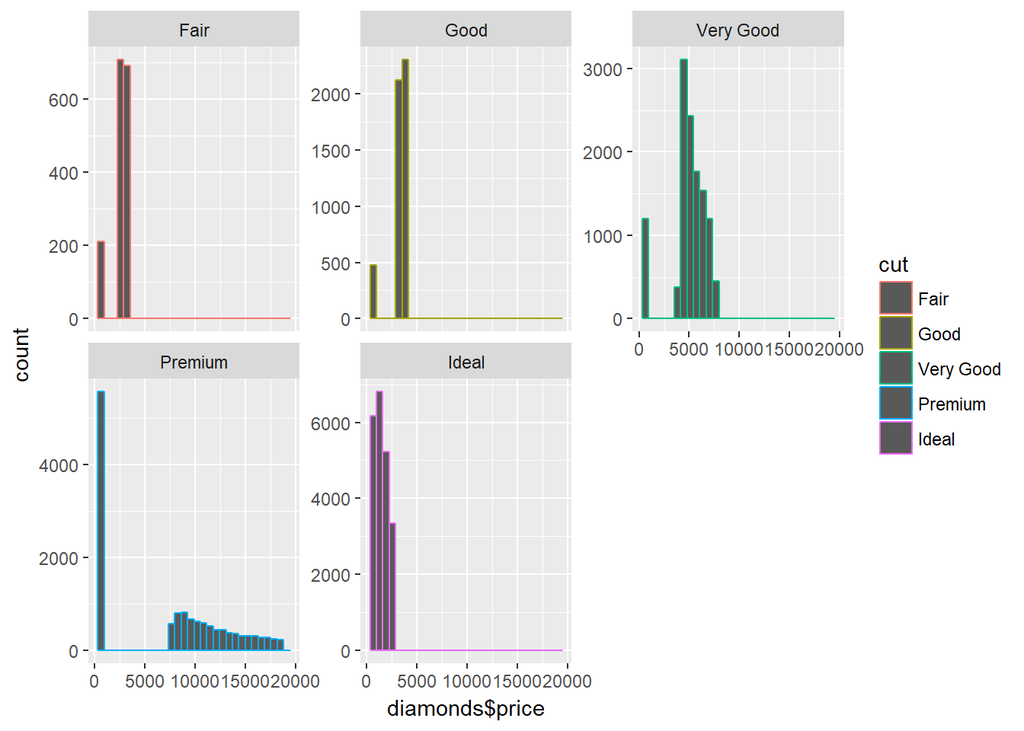

```r
ggplot(data = diamonds, aes(color = cut)) + geom_histogram(aes(x=diamonds$price))+facet_wrap(~cut, scales="free_y")
```

**Se observa que los precios que tienen más variacion son los del corte *Premiun* y también los precios más altos, mientras que para el corte *Ideal* notamos que agrupa los diamantes con los precios más bajos**

## Ahora observaremos la distribución de los datos con el diagrama de cajas

### Para los datos agrupados por Clarity

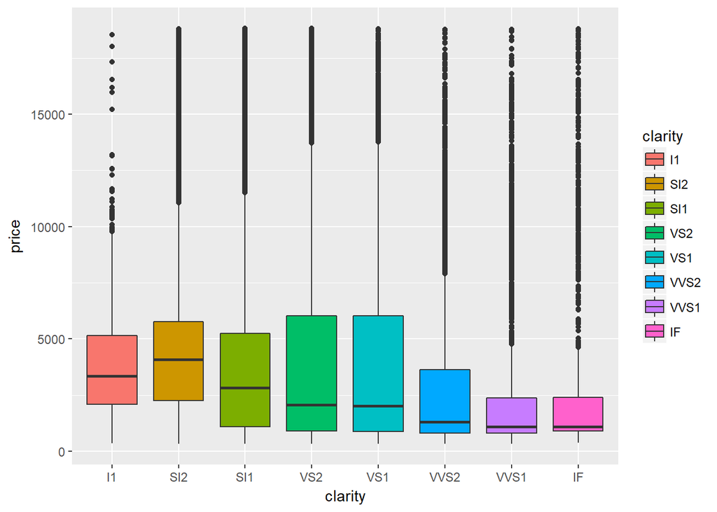

```r
ggplot(diamonds, aes(x = clarity, y=price, fill=clarity)) +
        geom_boxplot()
```

**Se nota que para la medida de claridad SI2(de la peor en la escale) tenemos el mayor peso**

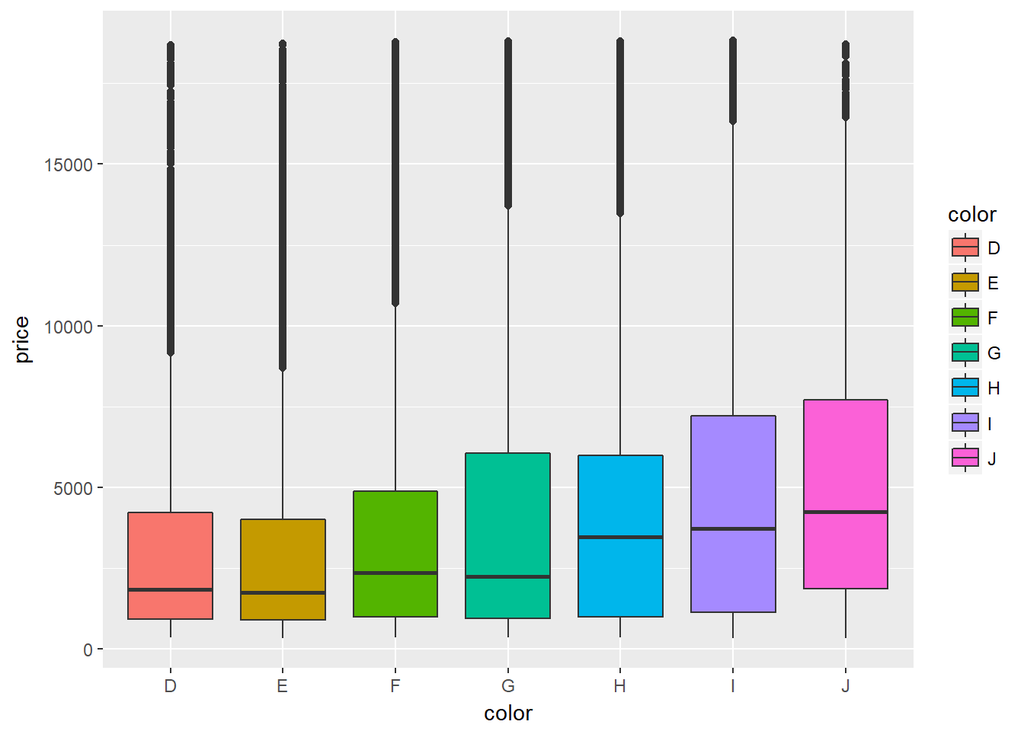

```r
ggplot(diamonds, aes(x = color, y=price, fill=color)) +
        geom_boxplot()
```

Las medidas para los diamante agrupados por color:

```r
by(diamonds$price, diamonds$color, summary)
```

```
## diamonds$color: D
##    Min. 1st Qu.  Median    Mean 3rd Qu.    Max.
##     357     911    1838    3170    4214   18693
## --------------------------------------------------------
## diamonds$color: E
##    Min. 1st Qu.  Median    Mean 3rd Qu.    Max.
##     326     882    1739    3077    4003   18731
## --------------------------------------------------------
## diamonds$color: F
##    Min. 1st Qu.  Median    Mean 3rd Qu.    Max.
##     342     982    2344    3725    4868   18791
## --------------------------------------------------------
## diamonds$color: G
##    Min. 1st Qu.  Median    Mean 3rd Qu.    Max.
##     354     931    2242    3999    6048   18818
## --------------------------------------------------------
## diamonds$color: H
##    Min. 1st Qu.  Median    Mean 3rd Qu.    Max.
##     337     984    3460    4487    5980   18803
## --------------------------------------------------------
## diamonds$color: I
##    Min. 1st Qu.  Median    Mean 3rd Qu.    Max.
##     334    1120    3730    5092    7202   18823
## --------------------------------------------------------
## diamonds$color: J
##    Min. 1st Qu.  Median    Mean 3rd Qu.    Max.
##     335    1860    4234    5324    7695   18710
```

**El color con la media de precio más alto es el J, según la descripcion de nuestro dataset es el peor color en la escala J-D**

### Agrupamos por color y claridad para observar la distribución:

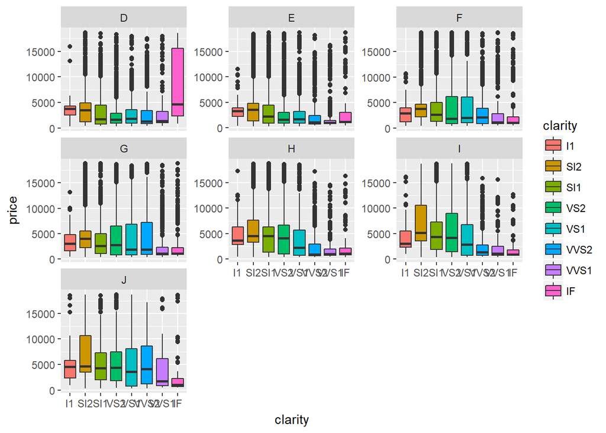

```r
ggplot(diamonds, aes(x = clarity, y=price, fill=clarity)) +
        geom_boxplot()+facet_wrap(~color, scales="free_y")
```

### Con la Variable Carats:

#### Para realizar el boxplot de la variable carats, debemos tomar en cuenta que esta variable es una variable continua

#### por lo que lo que haremos es categorizar esta variable en 4 grupos en un nueva variable llamada “fcarat” que añadiremos a nuestro set de datos

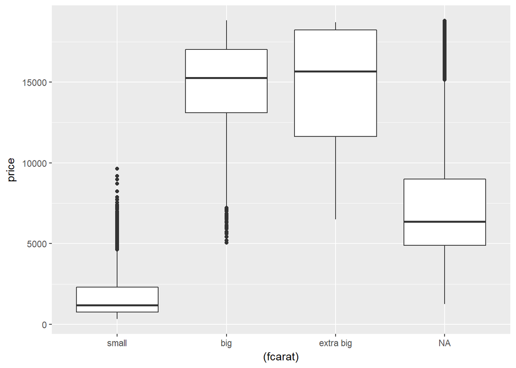

```r
diamonds$fcarat<-cut(diamonds$carat, c(0,1,2,3))
diamonds$fcarat <- "0"
diamonds$fcarat[diamonds$carat < 1] <- "small"
diamonds$fcarat[diamonds$carat >= 1 & diamonds$carat < 2] <- "medium"
diamonds$fcarat[diamonds$carat >= 2 & diamonds$carat < 3] <- "big"
diamonds$fcarat[diamonds$carat >= 3] <- "extra big"
diamonds$fcarat <- factor(diamonds$fcarat,  levels = c('small','middle', "big", "extra big"),ordered = TRUE)
ggplot(diamonds, aes(x = (fcarat), y=price)) +
        geom_boxplot()
```

```r
table(diamonds$fcarat)
```

```
##
##     small    middle       big extra big
##     34880         0      2114        40
```

y la distribución en porcentaje:

```r
prop.table(table(diamonds$fcarat))*100
```

```
##
##      small     middle        big  extra big
## 94.1837231  0.0000000  5.7082681  0.1080089
```

### De todo lo anterios podemos Extraer:

- Los diamantes más grandes (carat) tienen los precios más altos, aunque son mucho más raros de encontrar como se muestra en la tabla anterior, solo hay en nuestro dataset 2114 diamantes de tamaño “grande” (entre 2-3 quilates) y de tamaño “extra grande” (mayor a 3 quilate) soy hay 40.
- Las variables que pueden tener más peso en un modelo para predecir el precio son: carat, clarity, color y corte

# 3. Realizar un contraste de hipótesis para determinar si la media de carat es igual para las categorías cut-Fair y cut-Good).

##### La hipostesis nula es que la media son iguales, la hipotesis alterna las medias son distintas

##### para este test haremos uso de la funcion t.test

Primero separamos nuestro datos del dataset

```r
df_fair_good <- diamonds %>%
        filter(cut == "Fair" | cut == "Good") %>%
        select(cut, carat)
#Medidas de Tendencia central para Fair
summary(df_fair_good %>%
          filter(cut == "Fair") %>%
          .$carat)
```

```
##    Min. 1st Qu.  Median    Mean 3rd Qu.    Max.
##   0.220   0.700   1.000   1.046   1.200   5.010
```

```r
#Medidas de Tendencia Cental para Good
summary(df_fair_good %>%
          filter(cut == "Good") %>%
          .$carat)
```

```
##    Min. 1st Qu.  Median    Mean 3rd Qu.    Max.
##  0.2300  0.5000  0.8200  0.8492  1.0100  3.0100
```

### De los datos vemos que en promedio parece que para el Corte *Fair* la media es más alta que para el corte *Good*

#### Observamos los datos graficamente

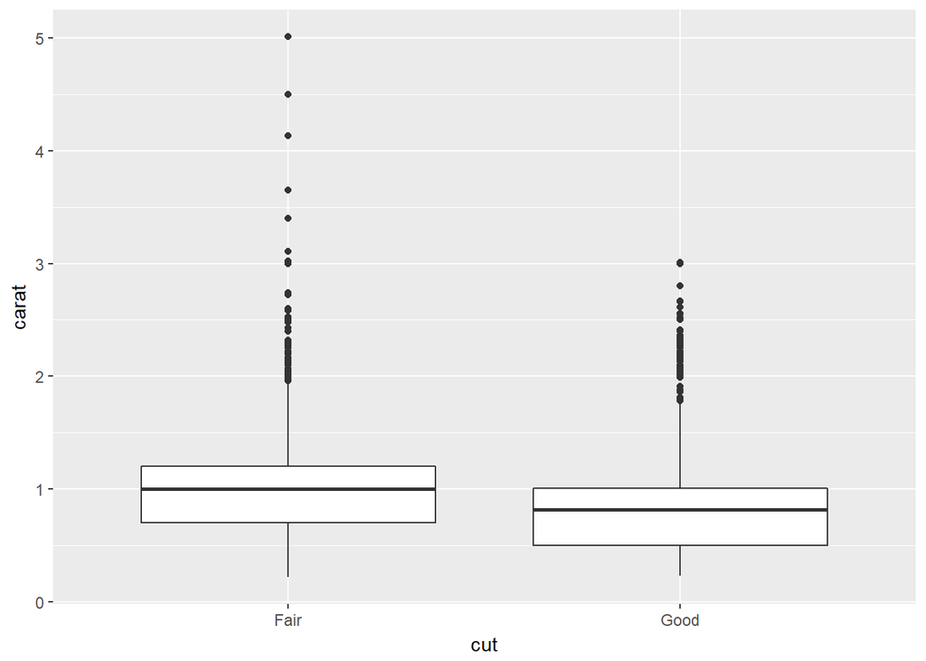

```r
ggplot(data = df_fair_good, aes(cut, carat)) +
        geom_boxplot()
```

### Estudiamos la normalidad de nuestros datos, para inferir si debemos realizar alguna transformacion antes de aplicar el t.test

- Chequeamos si los datos siguen una distribucion normal
- Asumimos que las variables son indenpendientes

## Si hacemos los histogramas de los datos agrupados por corte podemos observar que no siguen una distribucion normal

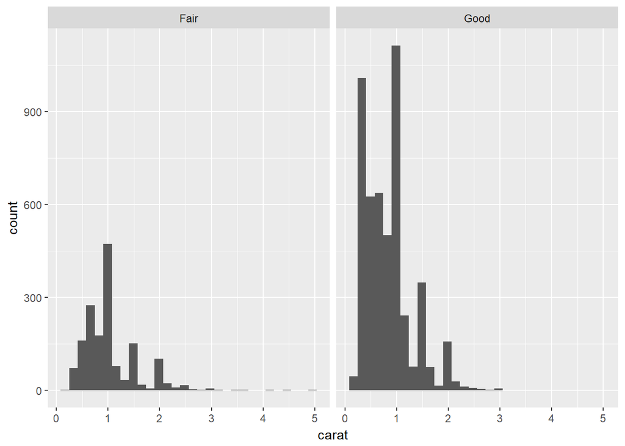

```r
ggplot(df_fair_good, aes(carat)) +
        geom_histogram() +
        facet_wrap(~ cut)
```

```r
ks.test((df_fair_good[df_fair_good$cut =="Good",]$carat), "pnorm")
```

```
##
##  One-sample Kolmogorov-Smirnov test
##
## data:  (df_fair_good[df_fair_good$cut == "Good", ]$carat)
## D = 0.59712, p-value < 2.2e-16
## alternative hypothesis: two-sided
```

Sin embargo asumimos que las medias siguen a la normal por el Teorema del Limite Central (TLC)

### Realizamos el t.test

```r
t.test(log(carat) ~ cut, data = df_fair_good)
```

[output not shown]

**En este caso tomamos el log de la variable**

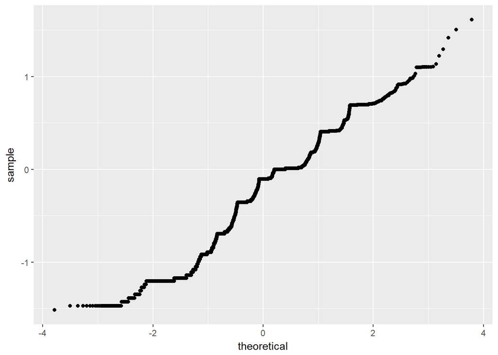

```r
ggplot(df_fair_good, aes(sample = log(carat)))+
       geom_point(stat = "qq")
```

y el histograma de la transformación:

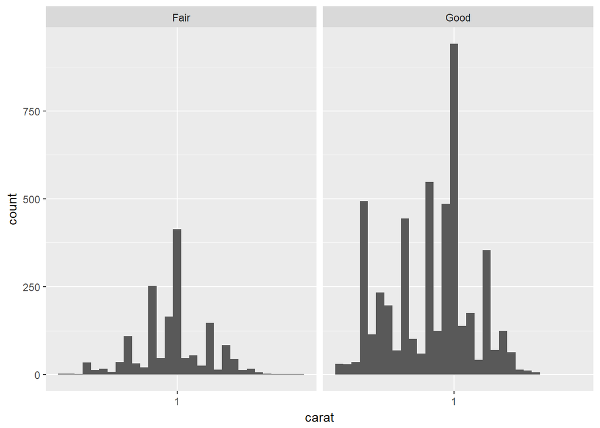

```r
ggplot(df_fair_good, aes(carat)) +
        geom_histogram() +
        facet_wrap(~ cut) +
        scale_x_log10()
```

Del grafico notamos que se acerca más a una normal, pero aùn no fielmente, in embargo por el TLC asumimos normalidad para las medias

### Volvemos a realizar el t.test

```r
t.test(log(carat) ~ cut, data = df_fair_good)
```

```
##
##  Welch Two Sample t-test
##
## data:  log(carat) by cut
## t = 17.44, df = 3186.4, p-value < 2.2e-16
## alternative hypothesis: true difference in means is not equal to 0
## 95 percent confidence interval:
##  0.2166251 0.2715032
## sample estimates:
## mean in group Fair mean in group Good
##        -0.06291157        -0.30697572
```

## **Extraemos entonces de los t.test realizados y del p-valor que rechazamos la hipótesis nula, ya que con un 95% de confianza la diferencia de las medias no es igual a 0, por lo que concluimos que las medias ó promedio son distintos**